# Tuango - RFM Analysis for Mobile App Push Messaging

- Name:
- GitLab id:

## Setup

Please complete this Rmarkdown document by answering questions 1-13 in `tuango.pdf` on Canvas (week4/). The code block below loads the data you need for this first Rmarkdown file. Create an HTML file with all your results and answers and push both the Rmarkdown and HTML file to GitLab when you are done. All results MUST be reproducible (i.e., the TA and I must be able to recreate the results without changes or errors)

Use “tuango_post.Rmd” to answer Question 14 in `tuango.pdf`

```r
## loading the data - this dataset must NOT be changed
tuango <- readr::read_rds("data/tuango.rds")
```

## Question answers

### Quesition1

```r
ifbuy <- tuango %>% count(buyer)
percentage = ifbuy[1,2]/nrow(tuango)
```

### Question2

```r
amount <- tuango %>%
  filter(buyer == 'yes') %>%
  summarise(average = mean(ordersize))
amount
```

```
# A tibble: 1 x 1
  average
    <dbl>
1    202.
```

### Question3

```r
# create new variable(s)
tuango <- mutate(tuango, rec_iq = xtile(recency, 5))
## create new variable(s)
tuango <- mutate(tuango, freq_iq = xtile(frequency, 5, rev = TRUE))
## create new variable(s)
tuango <- mutate(tuango, mon_iq = xtile(monetary, 5, rev = TRUE))
```

### Question4

```r
visualize(
  tuango,
  xvar = c("rec_iq", "freq_iq", "mon_iq"),
  yvar = "buyer",
  type = "bar",
  custom = FALSE
)
```

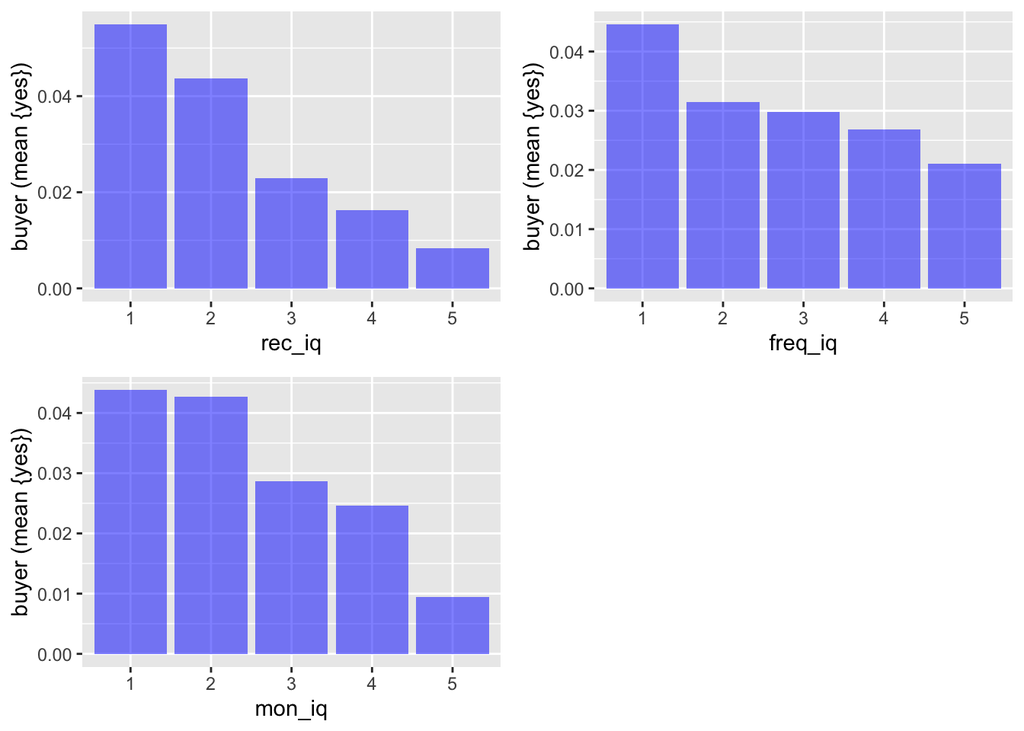

### Question5

```r
visualize(
  tuango,
  xvar = c("rec_iq", "freq_iq", "mon_iq"),
  yvar = "ordersize",
  type = "bar",
  data_filter = "buyer == 'yes'",
  custom = FALSE
)
```

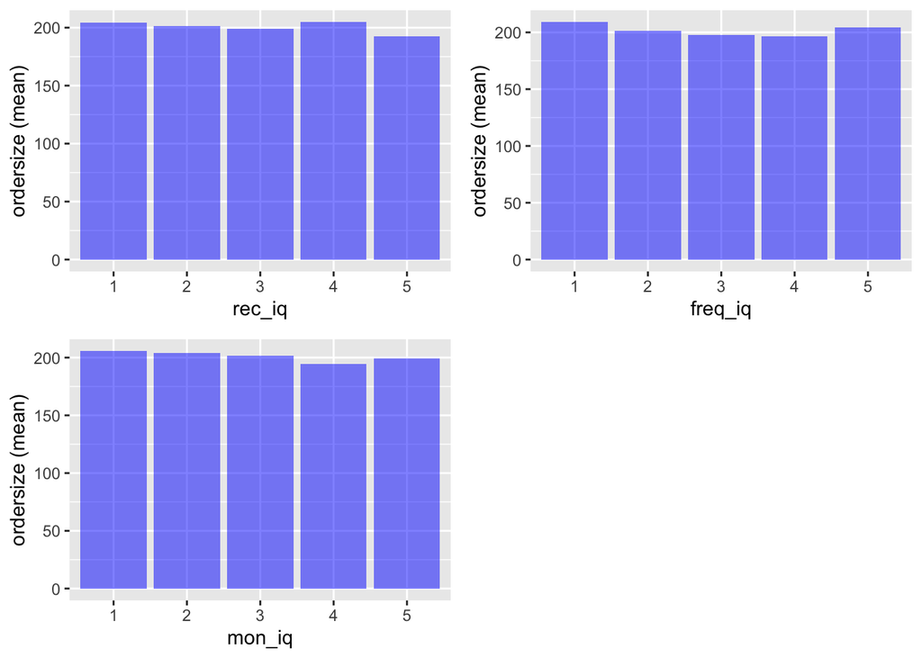

### Question6

The above bar plot reveals that the likelihood of response is positively related to RFM.The more recency, frequently and monetary value, the higher likelihood of response. For the size of the order across all recency, frequency and monetary quantiles, the trend of the graph is moderate that it’s almost a horizontal line among different quantiles.

### Question7

```r
## create new variable(s)
tuango <- mutate(tuango, rfm_iq = paste0(rec_iq, freq_iq, mon_iq))

## create new variable(s)
tuango <- group_by(tuango, rec_iq) %>%
  mutate(freq_sq = xtile( frequency, 5, rev = TRUE)) %>%
  ungroup()
## create new variable(s)
tuango <- group_by(tuango, rec_iq, freq_sq) %>%
  mutate(mon_sq = xtile(monetary, 5, rev= TRUE)) %>%
  ungroup()
## create new variable(s)
tuango <- mutate(tuango, rfm_sq = paste0(rec_iq, freq_sq, mon_sq))


margin <- amount*0.5
cost <- 2.5
breakeven <- cost/margin
breakeven
```

```
     average
1 0.02473671
```

### Question8

```r
n <- 250902
response <- n * percentage
profit <- margin*response - cost*n
ROME <- profit/(cost*n)
```

### Question9

```r
tuango_iq <- tuango %>%
  group_by(rfm_iq) %>%
  summarize(resp_rate = mean(buyer == "yes"))%>%
  left_join(tuango) %>%
  filter(resp_rate > 0.02473671) %>%
  summarise(perc = n()/nrow(tuango), resp = mean(resp_rate),
            profit = perc*amount*resp*n*0.5 - cost*n*perc, ROME = profit/(cost*n*perc))

profit_iq <-tuango_iq$profit
ROME_iq<-tuango_iq$ROME

tuango_sq <- tuango %>%
  group_by(rfm_sq) %>%
  summarise(resp_rate = mean(buyer == "yes")) %>%
  left_join(tuango) %>%
  filter(resp_rate > 0.02473671) %>%
  summarise(perc = n()/nrow(tuango), resp = mean(buyer == 'yes'),
            profit = perc*amount*resp*n*0.5 - cost*n*perc, ROME = profit/(cost*n*perc))
profit_sq <-tuango_sq$profit
ROME_sq<-tuango_sq$ROME
print(profit_sq)
```

```
  average
1  336632
```

```r
print(ROME_sq)
```

```
  average
1 1.27223
```

### Question 10

```r
tuango %>% filter(rfm_iq != rfm_sq)
```

```
# A tibble: 10,262 x 17
   userid    recency frequency monetary rfm_iq_pre buyer ordersize platform category mobile_os rec_iq freq_iq mon_iq rfm_iq freq_sq mon_sq rfm_sq
   <chr>       <int>     <int>    <dbl> <chr>      <fct>     <dbl> <fct>       <int> <fct>      <int>   <int>  <int> <chr>    <int>  <int> <chr>
 1 U96495706     101         4     70   533        no            0 Browser         3 android        5       3      3 533          3      4 534
 2 U79189310      79         4     37.6 534        no            0 App             3 android        5       3      4 534          3      5 535
 3 U67701028      78         1     72.9 453        no            0 App             3 android        4       5      3 453          5      2 452
 4 U93348582      62         6     36.9 414        no            0 App             3 android        4       1      4 414          2      4 424
 5 U19691266      44         6     19.8 415        no            0 App             3 android        4       1      5 415          2      5 425
 6 U68753238      28         4    108   332        no            0 App             3 android        3       3      2 332          3      3 333
 7 U43344148      16         2     36   244        no            0 App             3 android        2       4      4 244          5      4 254
 8 U41921084      15         2     31   244        no            0 Browser         3 others         2       4      4 244          5      4 254
 9 U11113033      14         2     35   244        no            0 App             3 android        2       4      4 244          5      4 254
10 U67723307      13         6     19   215        no            0 App             3 android        2       1      5 215          2      5 225
# … with 10,252 more rows
```

The two approaches generally doesn’t yield the same RFM index for any given customer.Independent quantiles create 5 independent groups and each of them is analyzed independently.Sequential quantiles need to create 125 groups.I think sequential quantiles is a superior method. since for each recency quantile, we create frequency quantiles which is then divided into smaller monetary quantiles.This method is more accuate to predict the performance.

### Quesstion 11

```r
cell <- tuango %>%
  group_by(rfm_sq) %>%
  summarize(resp_rate = mean(buyer == "yes"), order = sum(ordersize)/sum(buyer == 'yes'),
            break_even = cost/(order*0.5)) %>%
  left_join(tuango) %>%
  filter(resp_rate > break_even) %>%
  summarise(perc = n()/nrow(tuango), resp = mean(buyer == 'yes'),
            profit = perc*amount*resp*n*0.5 - cost*n*perc, ROME = profit/(cost*n*perc))
profit_sq_cell <- cell$profit
ROME_sq_cell<-cell$ROME
print(profit_sq_cell)
```

```
   average
1 336168.6
```

```r
print(profit_sq_cell)
```

```
   average
1 336168.6
```

### Question 12

```r
tuango1 <- group_by(tuango, rfm_iq) %>%
  mutate(mailto_lbiq = (mean(buyer == "yes") - 1.64 * seprop(buyer == "yes")) > breakeven) %>%
  ungroup()
perc_mail <- mean(tuango1$mailto_lbiq)
nr_mail <- n * perc_mail
dat <- filter(tuango1, mailto_lbiq == TRUE)
rep_rate <- mean(dat$buyer == "yes")
nr_resp <- nr_mail * rep_rate
mail_cost_lbiq <- cost * nr_mail
profit_lbiq <- 0.5 * amount * nr_resp - mail_cost_lbiq
ROME_lbiq <- profit_lbiq / mail_cost_lbiq
print(profit_lbiq)
```

```
   average
1 280372.4
```

```r
print(ROME_lbiq)
```

```
   average
1 2.058308
```

```r
tuango2 <- group_by(tuango, rfm_sq) %>%
  mutate(mailto_lbsq = (mean(buyer == "yes") - 1.64 * seprop(buyer == "yes")) > breakeven) %>%
  ungroup()
perc_mail <- mean(tuango2$mailto_lbsq)
nr_mail <- n * perc_mail
dat <- filter(tuango2, mailto_lbsq == TRUE)
rep_rate <- mean(dat$buyer == "yes")
nr_resp <- nr_mail * rep_rate
mail_cost_lbsq <- cost * nr_mail
profit_lbsq <- 0.5 * amount * nr_resp - mail_cost_lbsq
ROME_lbsq <- profit_lbsq / mail_cost_lbsq
print(profit_lbsq)
```

```
  average
1  283994
```

```r
print(ROME_lbsq)
```

```
   average
1 1.954166
```

### Question 13

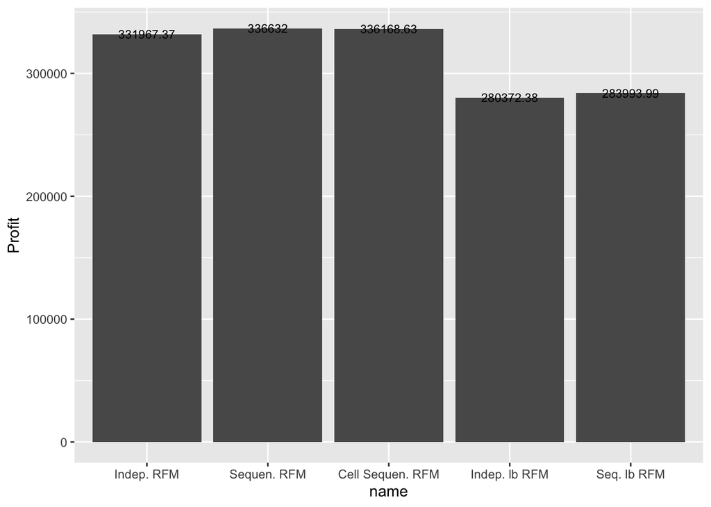

```r
results <- tibble::tibble(
  name = c("Indep. RFM", "Sequen. RFM", "Cell Sequen. RFM", "Indep. lb RFM", "Seq. lb RFM"),
  Profit = c(profit_iq, profit_sq, profit_sq_cell, profit_lbiq, profit_lbsq),
  ROME = c(ROME_iq, ROME_sq, ROME_sq_cell, ROME_lbiq, ROME_lbsq)
) %>%
  mutate(name = factor(name, levels = name))
results$Profit <- as.numeric(results$Profit)
results$ROME <- as.numeric(results$ROME)

results %>%
  ggplot(aes(x = name, y = Profit)) + geom_bar(stat = "identity") + geom_text(aes(label = round(Profit, 2)), size = 3)
```

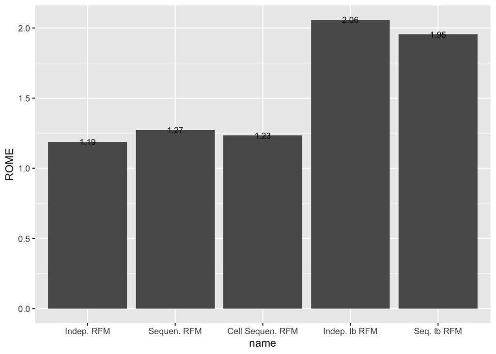

```r
results %>%
  ggplot(aes(x = name, y = ROME)) + geom_bar(stat = "identity") + geom_text(aes(label = round(ROME, 2)), size = 3)
```